# A summary of the tweets generated at ESA 2017 (#ESA2017)

E.J. Rollinson

## About this document

This document was produced by [Emily J. Rollinson](http://rollinsonecology.com) (ejrollinson on Twitter).

The code generating this document was originally developed by [Francois Michonneau](https://github.com/fmichonneau) (fmic_ on Twitter) for the 2015 Evolution meeting and can be found [here](https://github.com/fmichonneau/evol2015-tweets).

It has since been [adapted](https://github.com/jlehtoma/iccb2015-tweets/blob/gh-pages/index.Rmd) for ICCB-ECCB 2015 by Joona Lehtomaki (jlehtoma on Twitter).

Thanks also to Emily Sessa (ebsessa on Twitter) for reproducing this code for the 2015 Botany meeting, bringing it to my attention.

I originally adapted this code for the 2015 Ecological Society of America meeting (#ESA100) in Baltimore, MD, and have since reproduced it for [subsequent ESA and Botany meetings](https://erollinson.github.io/).

Tweets using the hashtag #ESA2017 were aggregated from Twitter using the R package [twitteR](https://cran.r-project.org/web/packages/twitteR/index.html) and the Twitter API. The aggregated tweets are [available on Figshare](https://figshare.com/articles/Tweets_using_ESA2017_hashtag/5306302).

This document was generated using RMarkdown, and the source is [available on GitHub](https://github.com/erollinson/erollinson.github.io).

This document (and associated code) is released under a CC0 licence.

## Basic summary

Of the 16995 tweets tagged #ESA2017 as of 2:30 PM EST 8/12/2017:

| Description | n |
| --- | --- |
| Total of original tweets (no retweets): | 8738 |
| Number of users who tweeted: | 3444 |

## The 5 most favorited tweets

> The Best Poster Ever Award goes to @Julian_Resasco. Wow! #ESA2017 https://t.co/UL6ML1HoSn

> — JacquelynGill | [2017-08-10](https://twitter.com/JacquelynGill/status/895770648940761088) | 185 retweets, 534 favorites.

> My daughter is having an amazing time at the poster session. If you explained your science to my 7 yr old daughter, thank you! #ESA2017

> — skmorgane | [2017-08-09](https://twitter.com/skmorgane/status/895143846669017088) | 23 retweets, 379 favorites.

> All these @500womensci at #ESA2017 throwing our some great ideas to make ESA more diverse, inclusive and equitable. https://t.co/cIzbc0U7qS

> — anjalikumar6 | [2017-08-09](https://twitter.com/anjalikumar6/status/895098882593505280) | 76 retweets, 272 favorites.

> Black ecologists representing #ESA2017 https://t.co/usEbuSgRtZ

> — SenayYitbarek | [2017-08-08](https://twitter.com/SenayYitbarek/status/894782782945107968) | 32 retweets, 255 favorites.

> Working on the plane to #ESA2017 and a tiny child says ‘that’s R stuff’ as they walk by. They start younger and younger these days :)

> — cmtucker_eco | [2017-08-06](https://twitter.com/cmtucker_eco/status/894307754898210816) | 20 retweets, 253 favorites.

## The 5 most retweeted tweets

> The Best Poster Ever Award goes to @Julian_Resasco. Wow! #ESA2017 https://t.co/UL6ML1HoSn

> — JacquelynGill | [2017-08-10](https://twitter.com/JacquelynGill/status/895770648940761088) | 185 retweets, 534 favorites.

> I’m recruiting a postdoc on a new NSF project on freshwater ecology, sensors, mgmt, & #DataScience: Let’s talk at #ESA2017 if interested!

> — CareyLab | [2017-08-06](https://twitter.com/CareyLab/status/894248838122418176) | 110 retweets, 64 favorites.

> If you couldn’t make advanced #vegan #rstats workshop @ #ESA2017 all the materials are freely avail: https://t.co/cf07XWD1rk #openscience

> — ucfagls | [2017-08-07](https://twitter.com/ucfagls/status/894350067968032768) | 90 retweets, 148 favorites.

> I am recruiting for a funded PhD position in evolutionary ecology. If you’re interested, come talk to me at #ESA2017 https://t.co/XWNrH08m9f

> — willpearse | [2017-08-07](https://twitter.com/willpearse/status/894656594889322496) | 89 retweets, 26 favorites.

> Recruiting new postdoc at #ESA2017. If you love ecosystems and data science consider joining StreamPULSE project. https://t.co/uboTwc7oxp

> — DrBioGC | [2017-08-07](https://twitter.com/DrBioGC/status/894615481725861888) | 87 retweets, 59 favorites.

## Top tweeters

All generated tweets (including retweets)

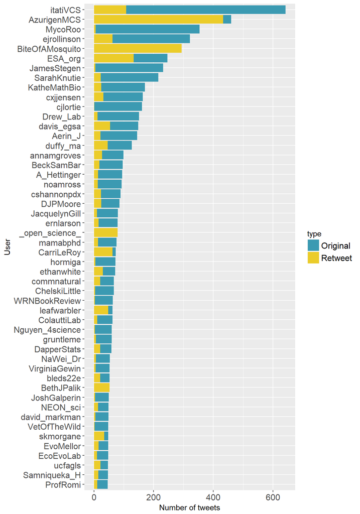

Only for original tweets (retweets excluded)

[figure not shown]

## Most favorited/retweeted users

The figures below only include users who tweeted 5+ times, and don’t include retweets.

### Number of favorites received by users

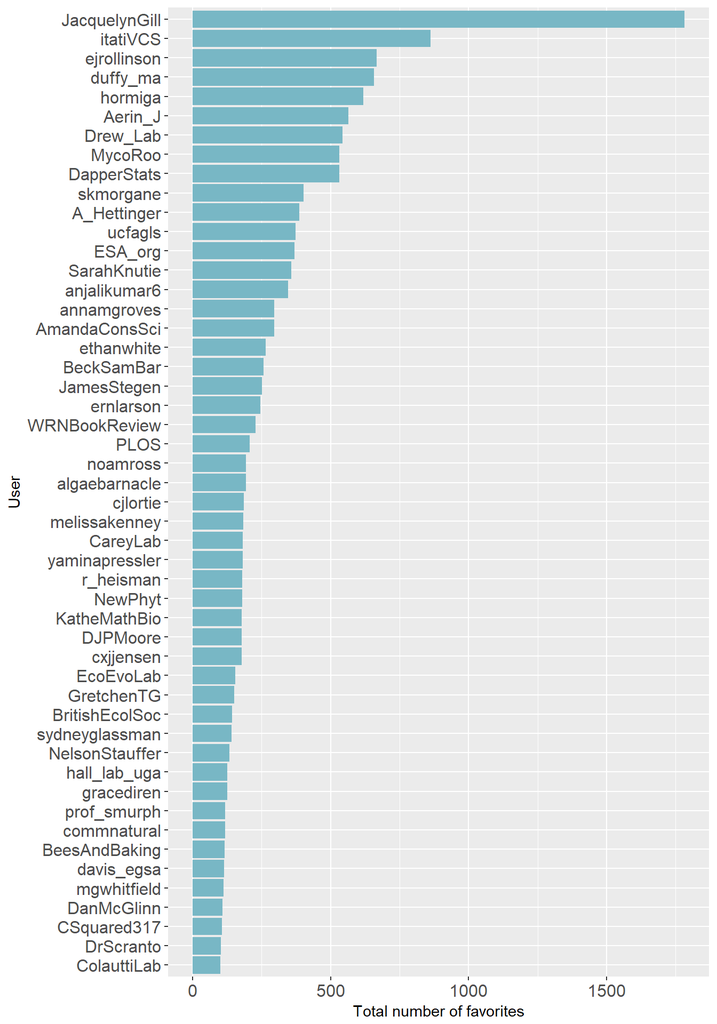

### Number of retweets received by users

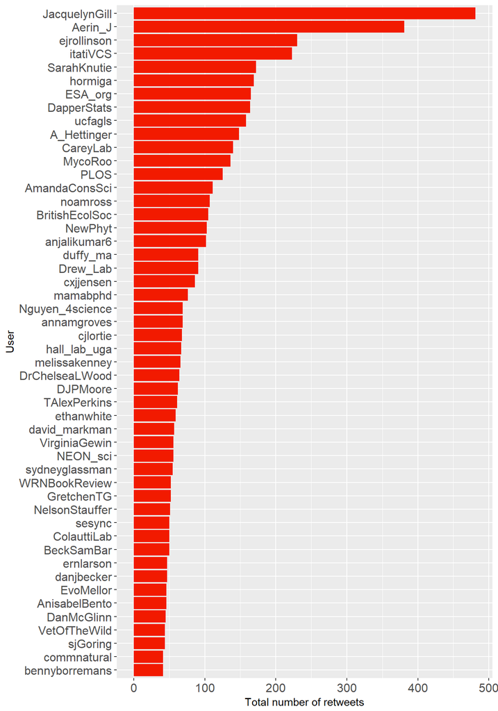

### Mean numbers of favorites received

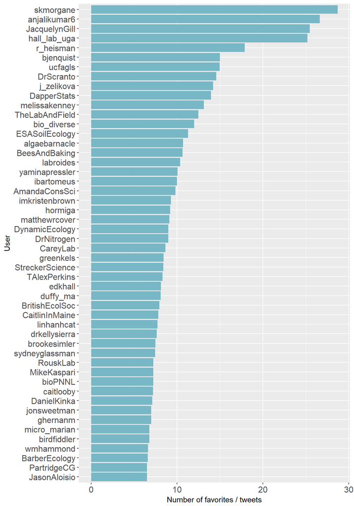

### Mean numbers of retweets received

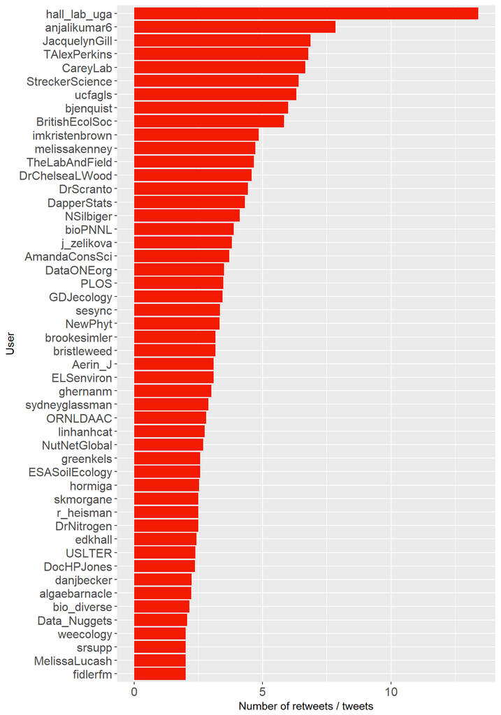

## Word cloud

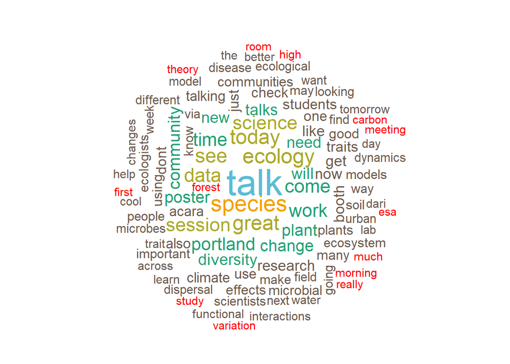

To the extent possible under law, [Emily J. Rollinson](https://github.com/erollinson/erollinson.github.io) has waived all copyright and related or neighboring rights to Summary of tweets at ESA 2017. This work is published from: United States.